# STAT3 : RELATION ENTRE DEUX VARIABLES QUANTITATIVES

## 2.1 Visualisation avec plot(X,Y)

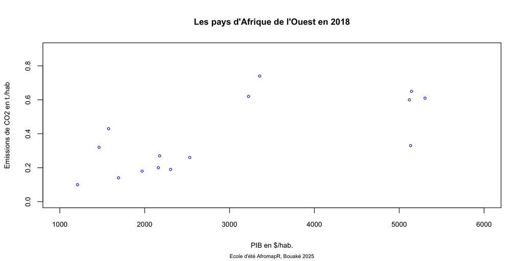

## 2.2 Identification des points avec **text(…)**

On peut ajouter au graphique généré par **plot(X,Y)** une couche de labels avec **text(X,Y,Code)**. On précise la position avec **pos =**, la taille de police avex **cex =** et la couleur avec **col =**.

```r
plot(sel$X,sel$Y,
     main = fr_titre,   # titre
     cex.main = 1,      # police du titre
     sub = fr_auteur,   # sous-titre
     cex.sub = 0.6,     # police du sous-titre
     xlab = fr_nomX,    # nom de l'axe X
     xlim = c(1000,6000),   # intervalle de l'axe X
     ylab = fr_nomY,    # nom de l'axe Y
     ylim = c(0,0.9),    # intervalle de l'axe Y
     cex.axis = 0.8,    # police des gradations d'axes
     cex.lab = 0.8,     # police des noms d'axes
     cex = 0.6,         # taille des symboles
     col = "blue")       # couleur des symboles
text(x = sel$X,
     y = sel$Y,
     label = sel$CODE,
     cex = 0.7,
     pos=3,
     col = "blue")
```

## 2.2 Identification des points avec **text(…)**

On peut ajouter au graphique généré par **plot(X,Y)** une couche de labels avec **text(X,Y,Code)**. On précise la position avec **pos =**, la taille de police avex **cex =** et la couleur avec **col =**.

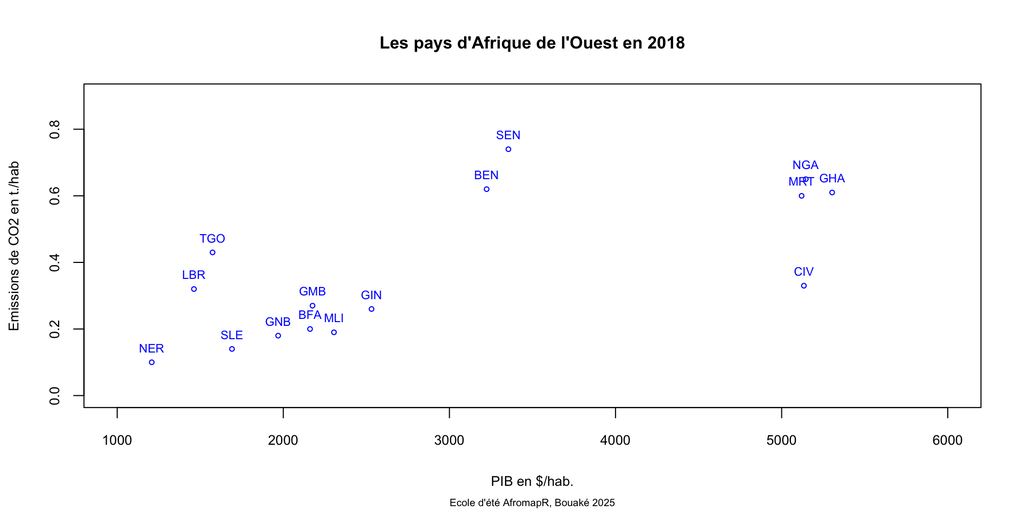

## 2.3 Ajout de lignes horizontales ou verticales avec **abline(…)**

On peut rajouter à un graphique des lignes horizontales ou verticales avec abline en précisant leur position avec **h=** ou **v=**, leur épaisseur avec **lwd =** , leur style avec **lty=** et leur couleur avec **col=**. On peut également ajouter la droite de régression linéaire Y = aX+b comme on le verra au chapitre suivant.

```r
plot(sel$X,sel$Y,
     main = fr_titre,   # titre
     cex.main = 1,      # police du titre
     sub = fr_auteur,   # sous-titre
     cex.sub = 0.6,     # police du sous-titre
     xlab = fr_nomX,    # nom de l'axe X
     xlim = c(1000,6000),   # intervalle de l'axe X
     ylab = fr_nomY,    # nom de l'axe Y
     ylim = c(0,0.9),    # intervalle de l'axe Y
     cex.axis = 0.8,    # police des gradations d'axes
     cex.lab = 0.8,     # police des noms d'axes
     cex = 0.6,         # taille des symboles
     col = "blue")       # couleur des symboles

text(x = sel$X,
     y = sel$Y,
     label = sel$CODE,
     cex = 0.6,
     pos=3,
     col = "blue")


# Ajout d'une ligne horizontale  correspondant à la moyenne de Y
abline(h=mean(sel$Y),col="red",lwd = 1, lty = 2)
# Ajout d'une ligne verticlae  correspondant à la moyenne de X
abline(v=mean(sel$X),col="red",lwd = 1, lty = 2)
```

## 2.3 Ajout de lignes horizontales ou verticales avec **abline(…)**

[figure not shown]

## 2.4 Interprétation du diagramme

Que vous apprend ce diagramme ? Quelles hypothèses permet-il de formuler ?

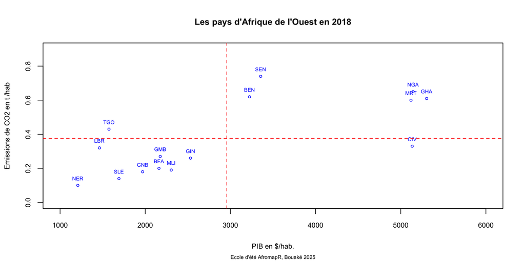

# 3. CORRELATION LINEAIRE

## 3.1 Définitions : relation linéaire/monotone/complexe

- il existe une **relation linéaire** entre deux variables quantitatives X et Y si l’on peut prédire leurs valeurs respectives par les fonctions **Y = a1.X + b1** et **X = a2.X = b2**
- il existe une **relation monotone** entre deux variables quantitatives X et Y si l’on peut prédire les valeurs Y en fonction de celle de X far une **fonction Y=f(X)** qui est **strictement croissante** ou **strictement décroissante**.
- il existe une **relation complexe** entre deux variables quantitatives X et Y si l’on peut prédire les valeurs Y en fonction de celle de X par une **fonction Y=f(X)** qui comporte au moins un point minimum ou maximum de changement de pente (**annulation de la dérivée première**)

## 3.1 Définitions : relation linéaire/monotone/complexe

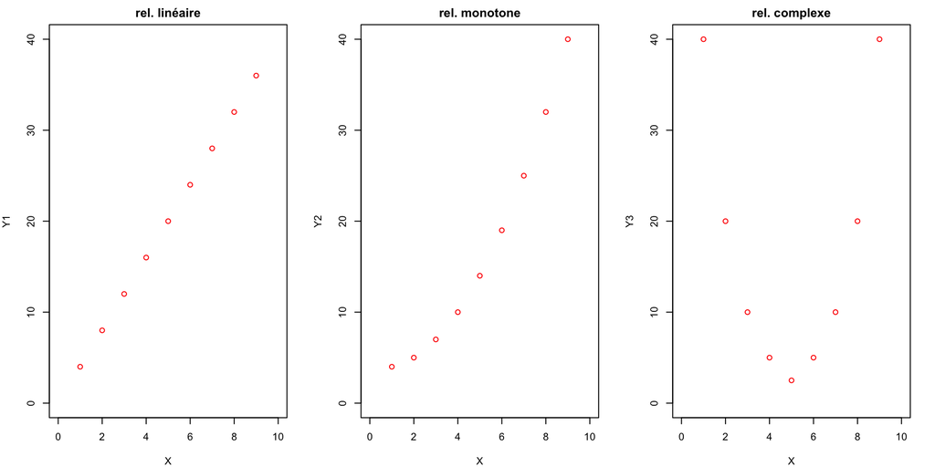

## 3.1 Définitions : relation positive/négative/nulle

- Une relation linéaire ou monotone est **positive** si à un accroissement de X correspond un accroissement de Y
- Une relation linéaire ou monotone est **négative** si à un accroissement de X correspond une diminution de Y
- une relation est **nulle** si une variation de X n’entraine pas de variation de Y

## 3.1 Définitions : relation positive/négative/nulle

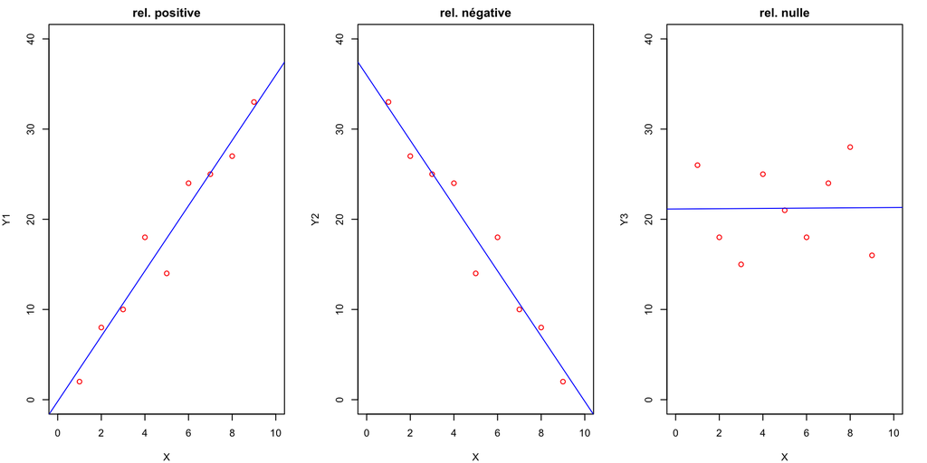

## 3.1 Définitions : relation forte/faible/nulle

- Une relation linéaire est **forte** si une valeur de X permet de prédire la valeur de Y avec une faible marge d’erreur.
- Une relation linéaire ou monotone est **faible** si une valeur de X permet de prédire la valeur de Y avec une forte marge d’erreur.
- une relation linéaire est **nulle** si une valeur de X ne permet aucunement de prédire la valeur de Y

## 3.1 Définitions : relation forte/faible/nulle

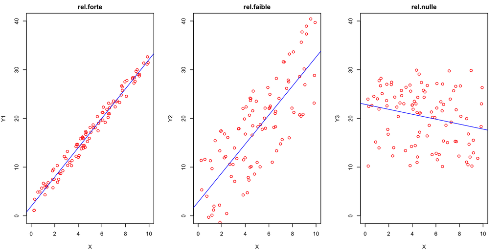

## 3.1 Définitions : relation significative/non siginificative

- Une relation linéaire est **significative** si l’effectif permettant de la mettre en évidence est suffisamment grand pour qu’on puisse exclure qu’elle soit l’effet du hasard.
- Une relation linéaire ou monotone est **non significative** si l’effectif permettant de la mettre en évidence n’est pas suffisamment grand pour qu’on puisse exclure qu’elle soit l’effet du hasard.
- On considère traditionnellement qu’une relation est significative s’il y a **moins de 5% de chances** qu’elle soit l’effet du hasard (**p-value < 0.05**).

## 3.1 Définitions : relation significative/non siginificative

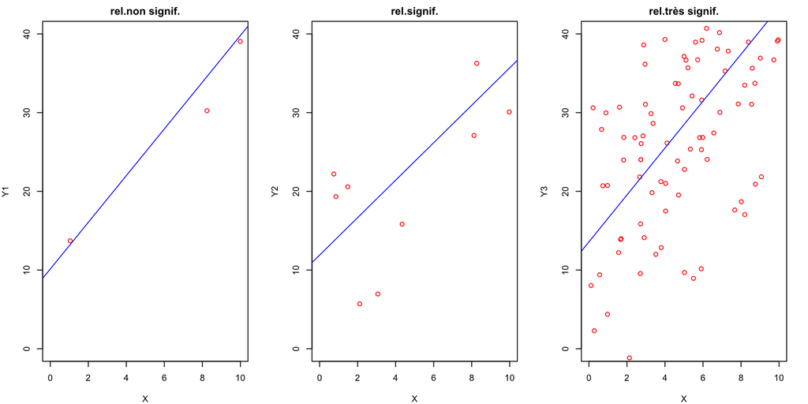

## 3.2 la fonction **cor()** : objectif

- La fonction **cor()** permet de mesurer le coefficient de corrélation de deux variable X et Y.
- Elle permet de détecter les **relations linéaires** en choisissant le paramètre (par défaut) **method = pearson**
- Elle permet de détecter **les relations non linéaires** en choisissant le paramètre **method = spearman** qui mesure l’existence d’une **relation monotone** entre les rangs de X et Y

## 3.2 la fonction **cor()** : syntaxe

- La syntaxe de la fonction **cor()** est très simple et permet de calculer trois types de corrélation. La méthode par défaut est **pearson** c’est-à-dire le coefficient de corrélation linéaire

```r
cor(sel$X,sel$Y)
```

```
[1] 0.6937868
```

```r
cor(sel$X,sel$Y, method = "spearman")
```

```
[1] 0.6964286
```

```r
cor(sel$X,sel$Y, method = "kendall")
```

```
[1] 0.5238095
```

## 3.2 **cor()** permet de savoir si la relation est linéaire ou monotone

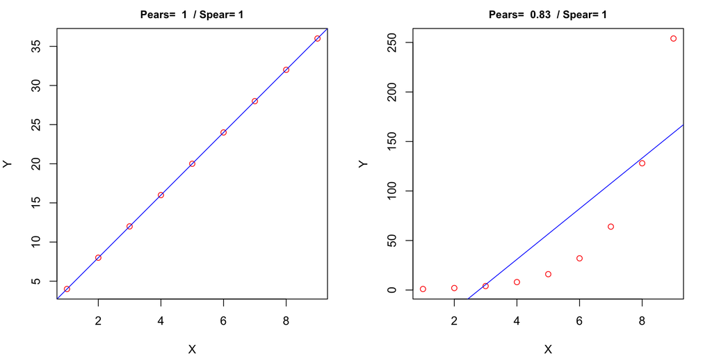

## 3.2 **cor()** permet de repérer l’effet d’une valeur exceptionnelle

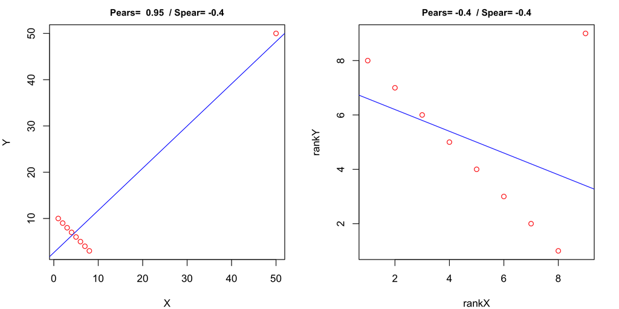

## 3.2 **cor()** permet de savoir si la relation est positive ou négative

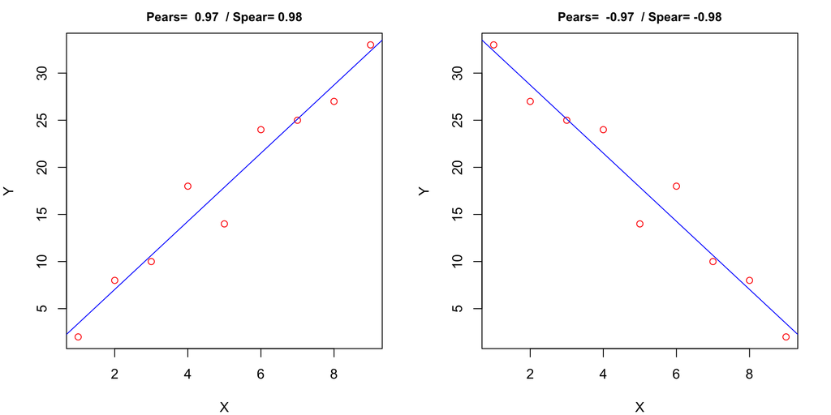

## 3.2 **cor()** permet de avoir si la relation est forte ou faible

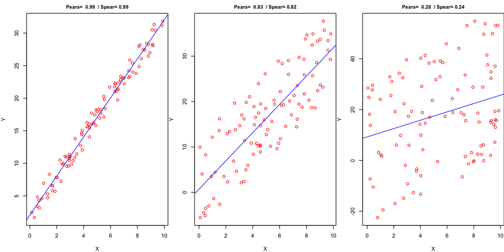

## 3.3. la fonction cor.test() : objectif

- la fonction **cor()** permet de savoir si une relation est forte ou faible, positive ou négative, linéaire ou non linéaire. Mais **cor() ne permet pas de savoir si une relation est significative ou pas.
- C’est la fonction **cor.test()** qui permet de **tester la significativité d’une relation** en fournissant un **intervalle de confiance du coefficient de corrélation** et une probabilité de rejet de H0 : il n’y a pas de relation appelée en anglais la **p-value**.
- p-value > 0.10 : relation non significative
- 0.10 > p-value > 0.05 : relation presque significative
- p-value < 0.05 : relation significative
- p-value < 0.01 : relation très significative

## 3.3. la fonction cor.test() : application au coefficient de Pearson

Même syntaxe que cor() :

```r
cor.test(sel$Y,sel$X)
```

```
    Pearson's product-moment correlation

data:  sel$Y and sel$X
t = 3.4734, df = 13, p-value = 0.004119
alternative hypothesis: true correlation is not equal to 0
95 percent confidence interval:
 0.2816077 0.8898101
sample estimates:
      cor
0.6937868
```

## 3.3. la fonction cor.test() : application au coefficient de Spearman

Même syntaxe que cor() :

```r
cor.test(sel$Y,sel$X, method="spearman")
```

```
    Spearman's rank correlation rho

data:  sel$Y and sel$X
S = 170, p-value = 0.005177
alternative hypothesis: true rho is not equal to 0
sample estimates:
      rho
0.6964286
```

## 3.4 Intensité et significativité

- Le carré du coefficient de corrélation appelé **r-square** ou **r2** permet de mesurer le pouvoir explicatif de X par rapport à Y. Il ne dépend pas du nombre d’observations.
- le test de significativité ou **p-value** mesure la significativité de la relation c’est-à-dire le fait que la relation entre X et Y ne soit pas l’effet du hasard. Il dépend à la fois du niveau de corrélation et du nombre d’observations.

## 3.4 Intensité et significativité

- A gauche : une relation forte mais non significative
- A droite : une relation faible mais très significative

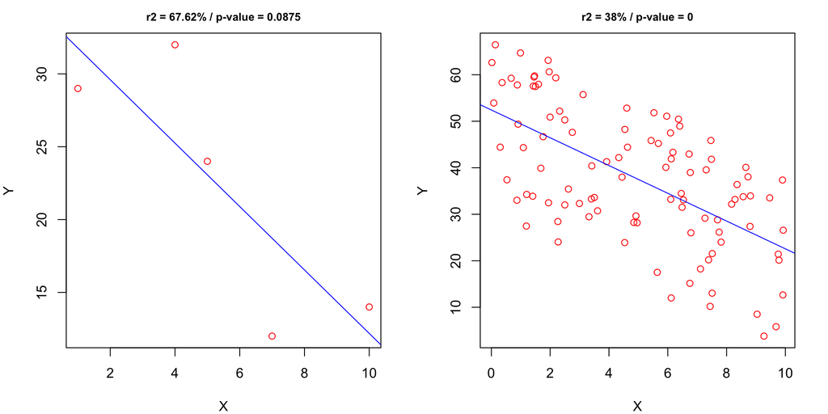

## 3.5 Conclusion : que pensez vous de la relation CO2 / PIB ?

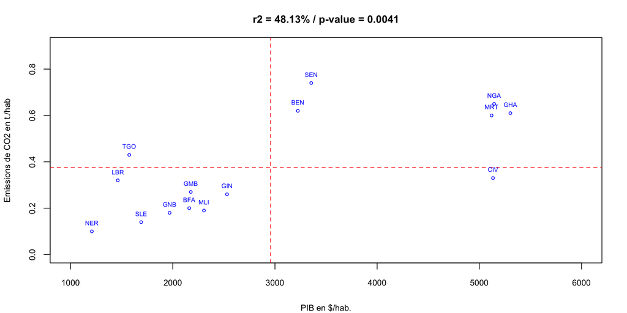

- positive ou négative ?
- forte ou faible ?
- linéaire ou non linéaire
- significative ou non siognificative ?

# 4. ANALYSE D’UNE MATRICE DE CORRELATION (Supplément facultatif)

## Objectif de l’analyse

- Soit un ensemble de variables quantitatives continues **$(X_1...X_i...X_k)$** décrivant les **mêmes individus**.
- On se propose de construire la matrice **$R_{ij}[1...i...k ; 1...j...k]$** indiquant pour chaque paire de variable $ij$ leur **coefficient de corrélation** (linéaire ou de rang)
- Puis de construire la matrice **$p_{ij}[1...i...k ; 1...j...k]$** indiquant pour chaque paire de variable $ij$ la probabilité H0 d’absence de relation, c’est-à-dire le degré de **significativité** de la corrélation.

## Utilisation des résultats

1. Mettre en évidence des **groupes de variables significativement corrélées entre elles**, que ce soit de façon positive ou négative.
2. Préparer la réalisation d’une **analyse en composantes principales** qui regroupera les variables corrélées entre elles en facteurs.
3. Identifier des variables non redondantes pour construire un modèle de **régression multiple**.
4. Indentifier des variables fortement corrélées pouvant servir de proxy pour estimer des **valeurs manquantes** dans un tableau

## Visualisation d’une matrice de corrélation

_ Sous la forme de **tableaux** montrant si possible à la fois les coefficients de corrélation et les seuils de significativité.

- Sous la forme de **graphes** montrant de façon visuelle l’intesité, le signe et la significativité des relations.
- Sous la forme de **plans factoriels** résultant d’une analyse en composantes principales.

Chacun de ces objectifs supposant en général l’emploi de packages spécialisés.

## Exemple : création d’un tableau quantitatif

On ne sélectionne que des variables quantitatives et on ajoute les noms des pays en attribut des lignes afin de former une **matrice**.

```r
tab<-don[,c(4:9)]
row.names(tab)<-don$iso3
head(tab,3)
```

```
     PIB CO2HAB ESPVIE AGEMED MORINF URBANI
BEN 3224   0.62   61.6   18.8   60.5   47.6
BFA 2161   0.20   61.4   17.6   49.0   29.7
CIV 5134   0.33   57.6   18.9   59.4   51.0
```

## Utilisation de la fonction cor()

On applique la fonction cor()

```r
mat_cor<-cor(tab)
```

On affiche la matrice de corrélation en arrondissant les valeurs

```r
round(mat_cor,3)
```

```
          PIB CO2HAB ESPVIE AGEMED MORINF URBANI
PIB     1.000  0.694  0.013  0.481 -0.010  0.541
CO2HAB  0.694  1.000  0.388  0.519 -0.263  0.542
ESPVIE  0.013  0.388  1.000  0.144 -0.821  0.076
AGEMED  0.481  0.519  0.144  1.000 -0.136  0.657
MORINF -0.010 -0.263 -0.821 -0.136  1.000 -0.135
URBANI  0.541  0.542  0.076  0.657 -0.135  1.000
```

## Utilisation du package psych

La fonction *cor.test()* de Rbase ne permet pas de calculer les corrélations pour toute une matrice. Aussi on charge le package **psych** qui dispose d’une fonction *corr.test()* beaucoup plus puissante qui crée plusieurs matrices de résultats

```r
library(psych)
results<-psych::corr.test(tab)
names(results)
```

```
 [1] "r"      "n"      "t"      "p"      "p.adj"  "se"     "sef"    "adjust"
 [9] "sym"    "ci"     "ci2"    "ci.adj" "stars"  "Call"
```

## Utilisation du package psych

On retrouve la matrice des coefficiences de corrélation

```r
round(results$r,3)
```

```
          PIB CO2HAB ESPVIE AGEMED MORINF URBANI
PIB     1.000  0.694  0.013  0.481 -0.010  0.541
CO2HAB  0.694  1.000  0.388  0.519 -0.263  0.542
ESPVIE  0.013  0.388  1.000  0.144 -0.821  0.076
AGEMED  0.481  0.519  0.144  1.000 -0.136  0.657
MORINF -0.010 -0.263 -0.821 -0.136  1.000 -0.135
URBANI  0.541  0.542  0.076  0.657 -0.135  1.000
```

## Utilisation du package psych

Mais aussi la matrice des tests de significativité

```r
round(results$p,3)
```

```
         PIB CO2HAB ESPVIE AGEMED MORINF URBANI
PIB    0.000  0.058  1.000  0.626  1.000  0.444
CO2HAB 0.004  0.000  1.000  0.472  1.000  0.444
ESPVIE 0.963  0.153  0.000  1.000  0.003  1.000
AGEMED 0.070  0.047  0.610  0.000  1.000  0.101
MORINF 0.971  0.344  0.000  0.629  0.000  1.000
URBANI 0.037  0.037  0.788  0.008  0.631  0.000
```

## Utilisation du package psych

On peut aussi faire une jolie matrice colorée avec des tests de signficativité sous forme d’étoiles

```r
corPlot(tab, stars=TRUE, diag=FALSE)
```

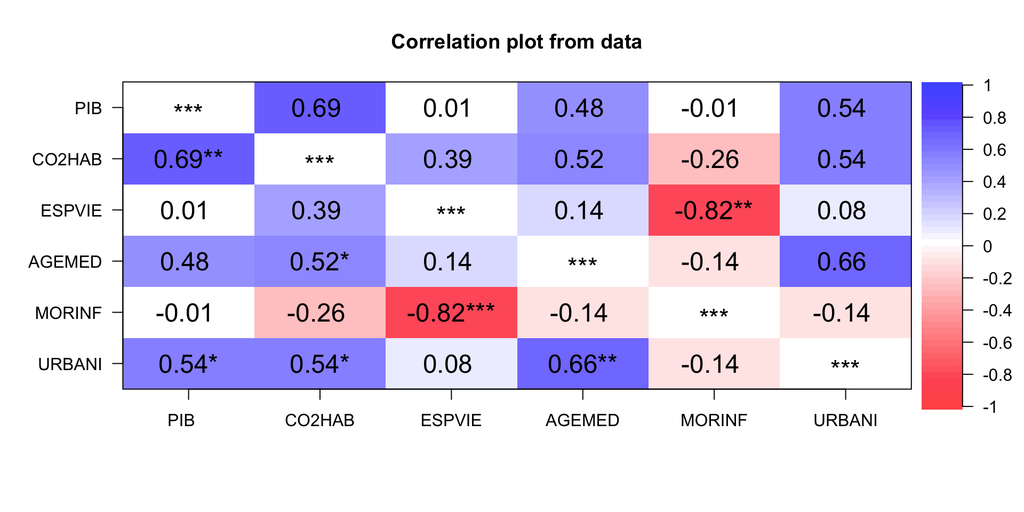

## Utilisation du package factoMineR

Si on veut voir les axes factoriels d’une analyse en composante principales on utilise la fonction *PCA()* de **FactoMineR**

```r
library(FactoMineR)
monacp<-PCA(tab, graph=FALSE)
```

On pourra ensuite visualiser la corrélation des variables avec les principaux axes factoriels et les coordonnées des individus sur ceux-ci.

## Corrélation des variables avec les axes factoriels

```r
plot.PCA(monacp,choix = "varcor")
```

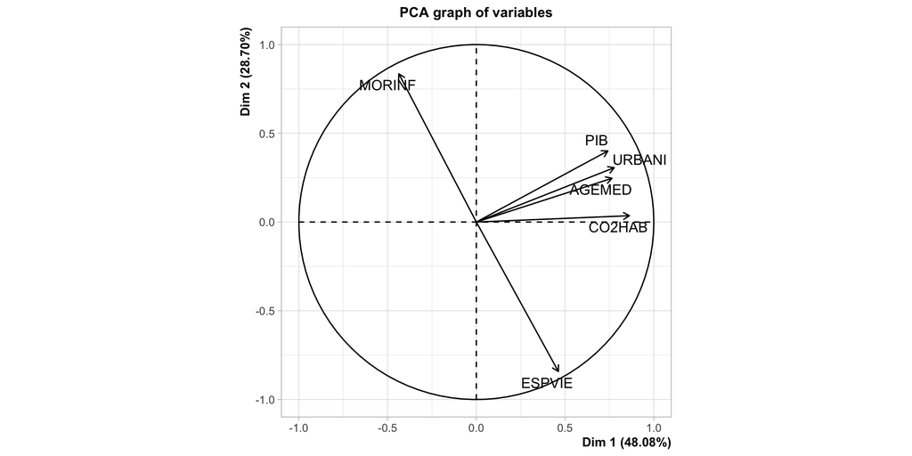

## Coordonnées des individus sur les axes factoriels

```r
plot.PCA(monacp,choix = "ind",)
```

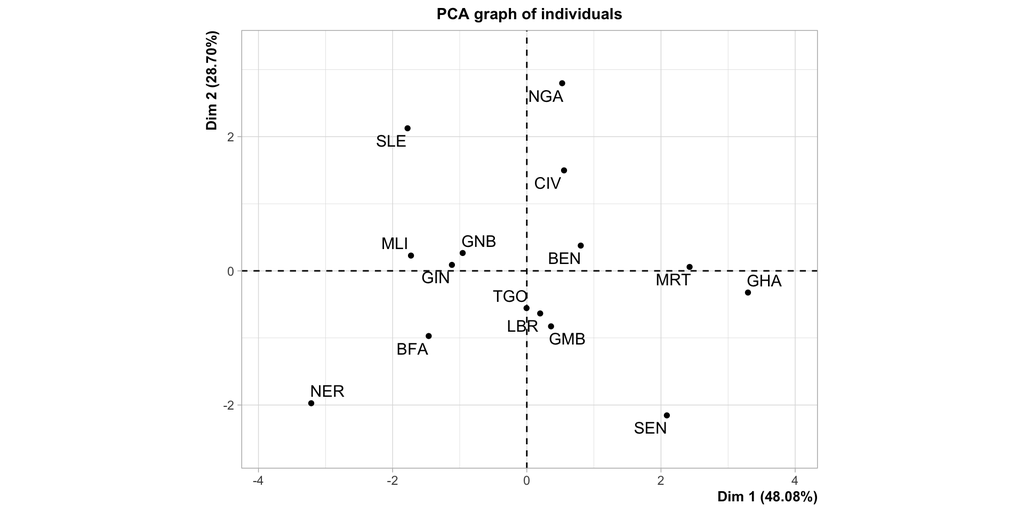